# ds202_lab3

Chase Weida; Github: cweida

2/19/2020

### 1

How does the happiness of a respondent relate to the marriage status?

```r
dat <- read_xls('../ds202_lab3/Data/GSS.xls')
```

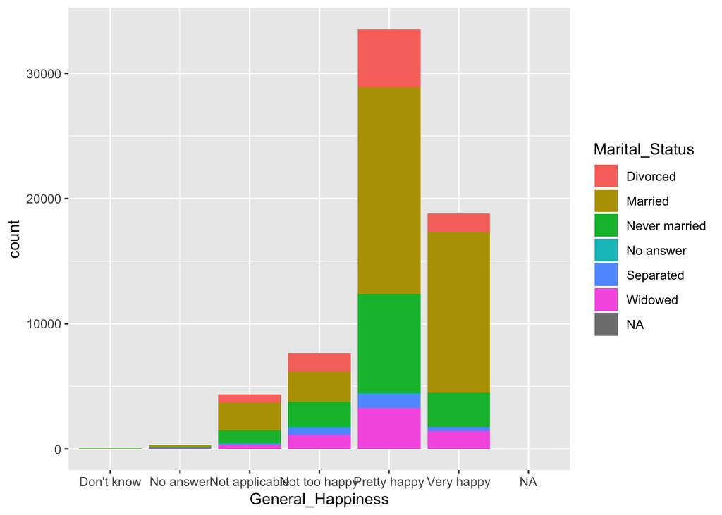

```r
colnames(dat) <- c("Year", "id", "Work_per_wk", "Marital_Status", "Spouse_Education", "Sex", "Political_Party", "General_Happiness", "Ballot_used")
ggplot(dat, aes(x = General_Happiness, fill = Marital_Status)) + geom_bar()
```

One can see that the “Pretty Happy” responders have much a much higher proportion of respondents who were never married. This is opposed to the “Very Happy” column which has a much higher number of respondents who are married.

### 2

Does the sex of the respondent affect the relationship you found in Q1?

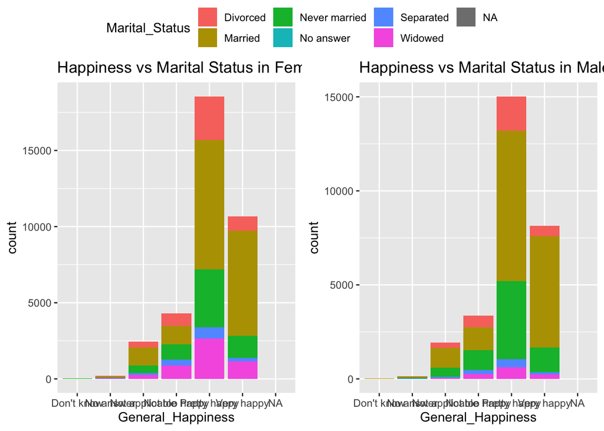

```r
plotMale <- ggplot(dat) + ggtitle('Happiness vs Marital Status in Females') + geom_bar(data = dat[dat$Sex == 'Female', ], aes(x = General_Happiness, fill = Marital_Status)) + theme(legend.position = "none")
plotFemale <- ggplot(dat) + ggtitle('Happiness vs Marital Status in Males') + geom_bar(data = dat[dat$Sex == 'Male', ], aes(x = General_Happiness, fill = Marital_Status))
ggarrange(plotMale, plotFemale, common.legend = TRUE)
```

### 3

How does the happiness of a respondent relate to the political party affiliation?

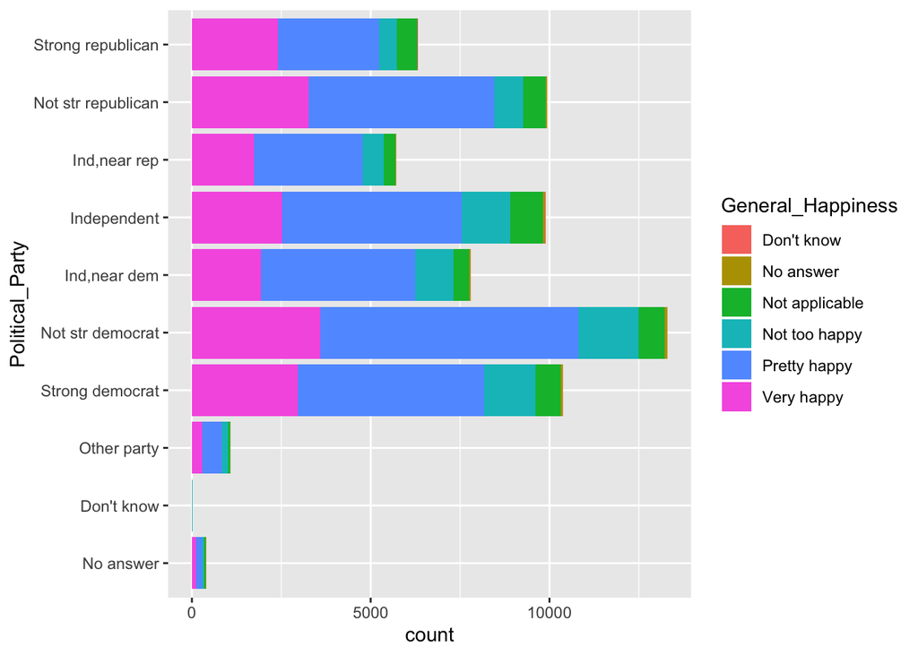

```r
dat1 <- dat[!is.na(dat$General_Happiness),]
dat1$Political_Party <- factor(dat1$Political_Party, levels=c("No answer", "Don't know", "Other party", "Strong democrat", "Not str democrat", "Ind,near dem", "Independent", "Ind,near rep", "Not str republican", "Strong republican"))
ggplot(dat1, aes(x = Political_Party, fill = General_Happiness))+ geom_bar() + coord_flip()
```

### 4a

How does the poltical party affiliation relate to the year the survey was conducted?

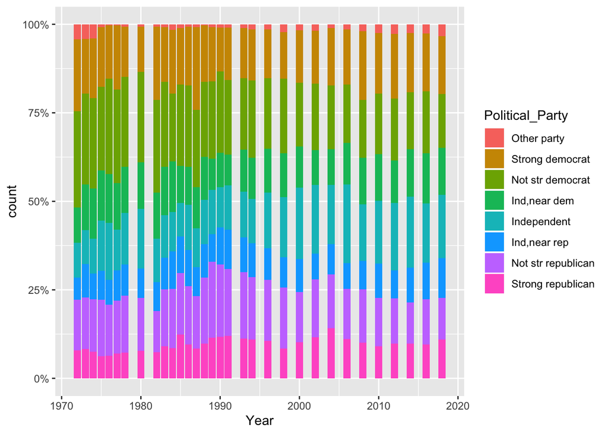

```r
dat2 <- dat[!(dat$Political_Party == "Don't know" | dat$Political_Party == "No answer"),]
dat2$Political_Party <- factor(dat2$Political_Party, levels=c("No answer", "Don't know", "Other party", "Strong democrat", "Not str democrat", "Ind,near dem", "Independent", "Ind,near rep", "Not str republican", "Strong republican"))
ggplot(dat2, aes(x = Year, fill = Political_Party)) +
  geom_bar(position = "fill") +
  scale_y_continuous(labels = scales::percent)
```

There was a rise in the number of Republicans and Republican leaning independents between 1980 and 1990 but then it went back down.

### 4b

What is the relation between marital status and political party affiliation?

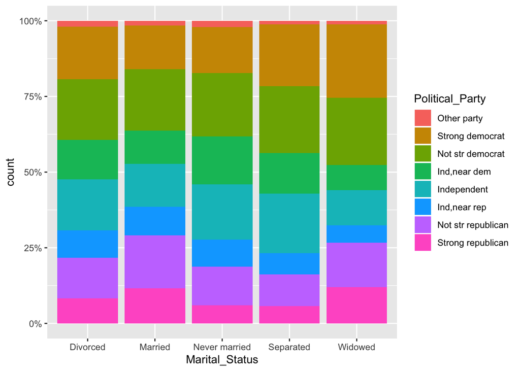

```r
dat3 <- dat[!(dat$Political_Party == "Don't know" | dat$Political_Party == "No answer" | is.na(dat$Political_Party)),]
dat3 <- dat3[!(is.na(dat3$Marital_Status) | dat3$Marital_Status == "No answer"),]
dat3$Political_Party <- factor(dat3$Political_Party, levels=c("No answer", "Don't know", "Other party", "Strong democrat", "Not str democrat", "Ind,near dem", "Independent", "Ind,near rep", "Not str republican", "Strong republican"))
ggplot(dat3, aes(x = Marital_Status, fill = Political_Party)) +
  geom_bar(position = "fill") +
  scale_y_continuous(labels = scales::percent)
```

It is more likely for a married or widowed person to be a Republican or a Republican leaning independent, than it is for a divorced, separated, or never married individual.

### 4c

Does a more highly educated spouse correlate to higher reported happiness?

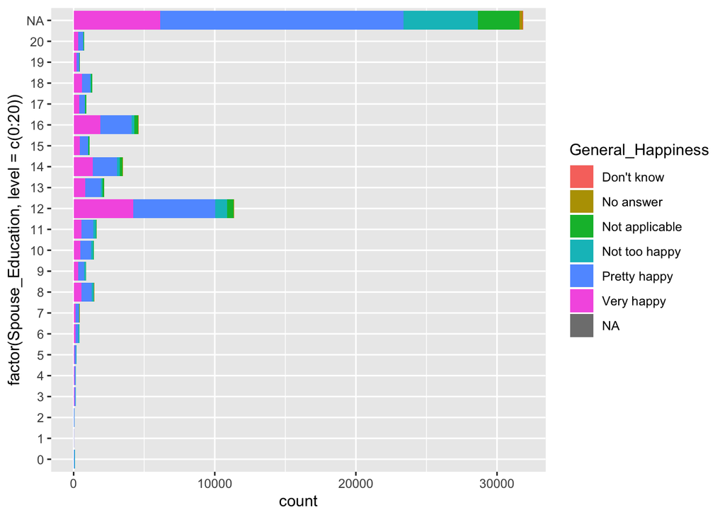

```r
ggplot(data = dat, mapping = aes(x = factor(Spouse_Education, level = c(0:20)), fill = General_Happiness)) + geom_bar() + coord_flip()
```

It appears as though most education levels share the same distribution of reported happiness levels.

### 4d

Does the sex of the respondent affect their political party affiliation?

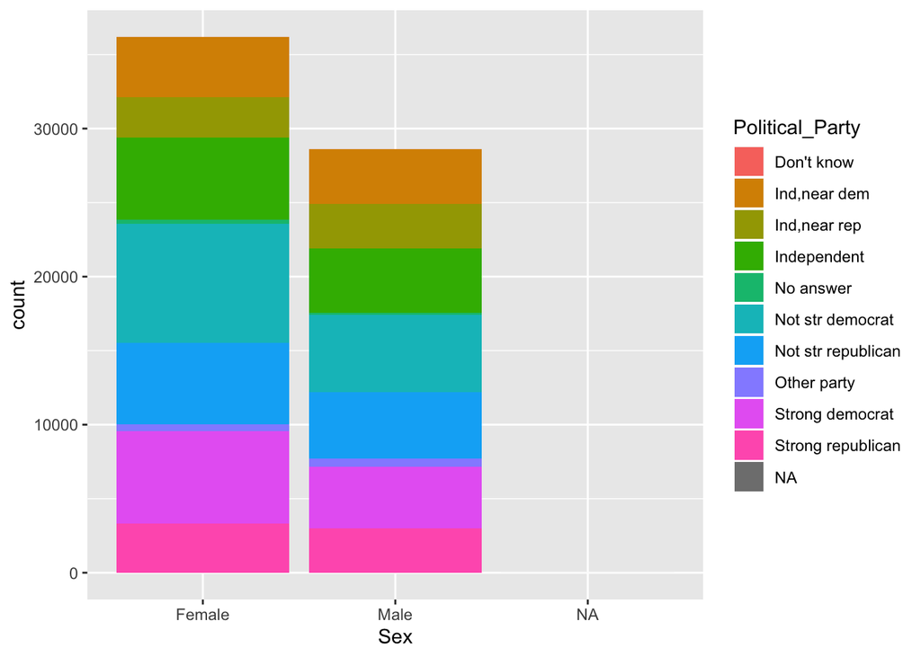

```r
ggplot(dat, aes(x = Sex, fill = Political_Party)) + geom_bar()
```

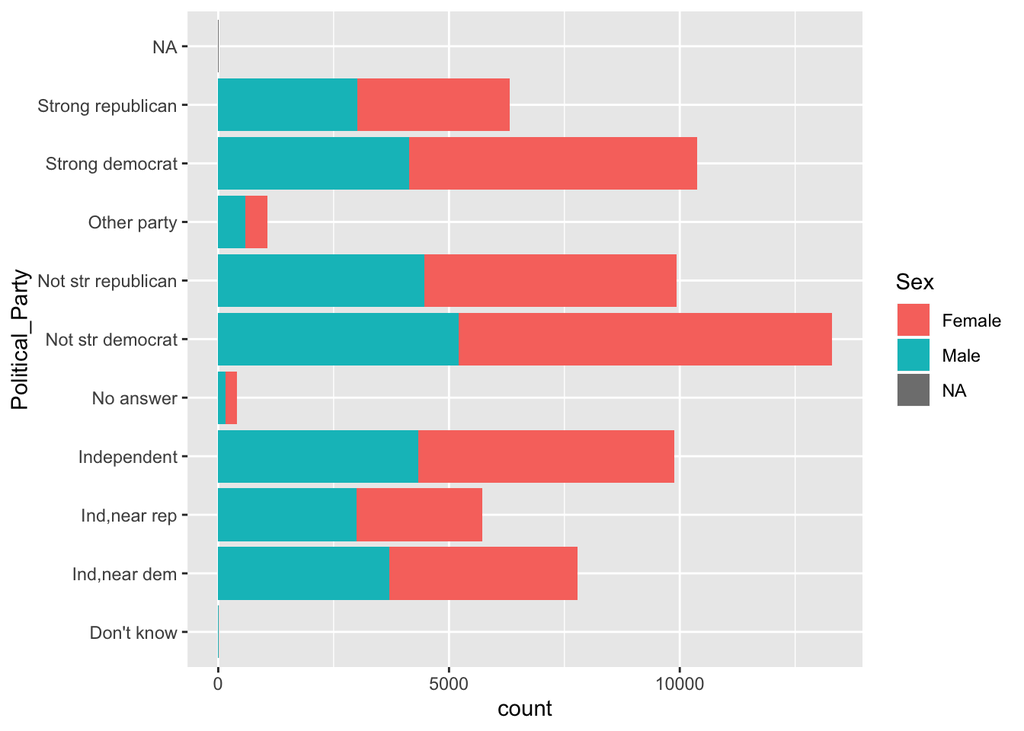

```r
ggplot(dat, aes(x = Political_Party, fill = Sex)) + geom_bar() + coord_flip()
```